[figure not shown]

# Análisis de Xbox Game Pass: Rentabilidad y Uso (2022)

## Introducción

Este proyecto tiene como objetivo evaluar el uso y la rentabilidad del servicio Xbox Game Pass durante el año 2022. Se analiza si los usuarios dedican tiempo a jugar títulos populares y bien valorados por la crítica. Los datos utilizados provienen de datasets disponibles en **Kaggle**, que incluyen información sobre las horas de juego y las puntuaciones en **Metacritic**, una plataforma que integra valoraciones de jugadores y críticos.

Xbox Game Pass es un servicio de suscripción de videojuegos que permite a los usuarios acceder a una biblioteca de juegos de alta calidad para consolas Xbox, PC y la nube por una tarifa mensual dependiendo de cada plan. A través de Game Pass, los usuarios pueden jugar a títulos nuevos y populares sin necesidad de comprarlos individualmente. Además, existen otros servicios similares en otras plataformas de los cuales se estiman los siguientes números:

- Xbox Game Pass: 29 millones de suscriptores
- Playstation Plus: 47 millones de suscriptores
- EA Play: 13 millones de suscriptoresv
- Nintendo Switch Online: 36 millones de suscriptores

Con estos números, se puede interpretar que Xbox Game Pass se queda muy por detrás con su competencia direccta. Por eso mismo, se realiza este análisis para responder unas preguntas clave:

- ¿Están aprovechando suficientes jugadores las ventajas del servicio?
- ¿Qué factores afectan realmente el número de jugadores? ¿Es la popularidad de los juegos el único determinante o existen otros elementos importantes?
- ¿Debería Xbox Game Pass centrarse en cierto tipo de juegos para atraer más suscriptores?

Con esto, se presenta el análisis realiizado.

## Imports

Primero, importamos las bibliotecas necesarias para el análisis y las funciones auxiliares desde la carpeta `utils`.

```python
import numpy as np
import matplotlib.pyplot as plt
import pandas as pd
import seaborn as sns
import re
import sys
sys.path.append('src/utils')

import constants as cons
import funciones as funtils
```

## Carga, tratamiento visualización de datos

Se cargan los datasets que se van a usar, se eliminan columnas innecesarias y se hace tratamiento de los valores en los registros de tal forma que los datos sean más sencillos de usar. Posteriormente, se unen los datasets para hacer el análisis

```python
df_gamepass = pd.read_csv(cons.DF_GAMEPASS_SRC_MAIN)
df_gamepass = df_gamepass.drop(columns=[cons.RATIO, cons.TRUE_ACHIVEMENTS, cons.GAME_SCORE])
df_gamepass.head()
```

|  | GAME | GAMERS | COMP % | TIME | RATING | ADDED |
| --- | --- | --- | --- | --- | --- | --- |
| 0 | Mass Effect Legendary Edition | 84,143 | 4.1 | 100-120 hours | 4.8 | 06 Jan 22 |
| 1 | The Elder Scrolls V: Skyrim Special Edition | 213,257 | 8.0 | 80-100 hours | 4.7 | 15 Dec 20 |
| 2 | Mass Effect 2 | 221,178 | 9.6 | 50-60 hours | 4.7 | 09 Nov 20 |
| 3 | Stardew Valley | 51,530 | 1.0 | 150-200 hours | 4.7 | 02 Dec 21 |
| 4 | It Takes Two | 71,981 | 15.6 | 12-15 hours | 4.7 | 03 Nov 21 |

Visualizamos la información general del DataFrame para entender mejor la estructura de los datos.

```python
df_gamepass.info()
```

```
<class 'pandas.core.frame.DataFrame'>
RangeIndex: 455 entries, 0 to 454
Data columns (total 6 columns):
 #   Column  Non-Null Count  Dtype
---  ------  --------------  -----
 0   GAME    455 non-null    object
 1   GAMERS  455 non-null    object
 2   COMP %  455 non-null    float64
 3   TIME    421 non-null    object
 4   RATING  452 non-null    float64
 5   ADDED   454 non-null    object
dtypes: float64(2), object(4)
memory usage: 21.5+ KB
```

Existen nulos en algunas columnas y la columna GAMERS no es numerica. Además, es conveniente modificar la columna TIME de tal forma que sea el tiempo medio y así el análisis sea más sencillo.

Antes de hacer cambios, se revisan los nulos que existen en TIME

```python
df_gamepass[df_gamepass[cons.TIME].isnull()].sort_values(by= cons.GAMERS, ascending=False)
```

|  | GAME | GAMERS | COMP % | TIME | RATING | ADDED |
| --- | --- | --- | --- | --- | --- | --- |
| 423 | Bassmaster Fishing 2022 | 9,425 | 0.0 | NaN | 2.4 | 09 Oct 21 |
| 242 | Fight Night Champion | 84,000 | 0.0 | NaN | 3.6 | 09 Nov 20 |
| 345 | Astria Ascending | 8,446 | 0.4 | NaN | 3.3 | 18 Sep 21 |
| 431 | Next Space Rebels | 8,091 | 0.3 | NaN | 3.2 | 17 Nov 21 |
| 448 | The Catch: Carp Coarse Fishing | 8,084 | 0.0 | NaN | 2.7 | 18 May 21 |
| 436 | Chinatown Detective Agency | 738 | 0.0 | NaN | 2.6 | 07 Apr 22 |
| 444 | Phoenix Point | 7,388 | 0.0 | NaN | 3.6 | 01 Oct 21 |
| 91 | Elite: Dangerous | 66,416 | 0.0 | NaN | 4.1 | 24 Feb 21 |
| 437 | RESEARCH and DESTROY | 6,162 | 0.1 | NaN | 3.1 | 26 Apr 22 |
| 427 | Unsouled | 4,302 | 0.0 | NaN | 3.1 | 28 Apr 22 |
| 433 | The Dungeon of Naheulbeuk: The Amulet of Chaos... | 4,273 | 0.1 | NaN | 4.1 | 17 Mar 22 |
| 451 | The Evil Within (JP) | 388 | 12.1 | NaN | 3.8 | 16 Aug 21 |
| 429 | Undungeon | 386 | 0.0 | NaN | 2.5 | 19 Nov 21 |
| 442 | Galactic Civilizations III (Windows) | 348 | 0.0 | NaN | 3.1 | 16 Mar 22 |
| 438 | Loot River | 334 | 0.0 | NaN | 3.2 | Yesterday |
| 420 | UNSIGHTED | 3,684 | 0.5 | NaN | 3.6 | 10 Sep 21 |
| 336 | NBA LIVE 19 | 29,473 | 0.1 | NaN | 3.3 | 09 Nov 20 |
| 421 | Lemnis Gate | 2,739 | 0.4 | NaN | 3.3 | 10 Sep 21 |
| 294 | NBA 2K22 | 18,528 | 0.0 | NaN | 3.5 | 28 Apr 22 |
| 204 | Train Sim World 2 | 17,494 | 0.0 | NaN | 3.8 | 19 Aug 21 |
| 428 | Fae Tactics | 166 | 0.0 | NaN | 3.0 | 18 Nov 21 |
| 414 | Library Of Ruina | 14,668 | 0.0 | NaN | 2.2 | NaN |
| 365 | Edge of Eternity | 14,114 | 0.0 | NaN | 3.2 | 31 Jan 22 |
| 393 | Power Rangers: Battle for the Grid | 13,851 | 0.4 | NaN | 2.9 | 26 Mar 20 |
| 384 | Nuclear Throne | 12,261 | 0.0 | NaN | 3.0 | 09 Sep 21 |
| 368 | Crown Trick | 12,253 | 0.0 | NaN | 3.2 | 03 Sep 21 |
| 46 | Stellaris: Console Edition | 11,695 | 0.0 | NaN | 4.3 | 16 Dec 19 |
| 441 | Crusader Kings III | 11,456 | 0.0 | NaN | 3.8 | 14 Mar 22 |
| 419 | NBA 2K22 (Xbox One) | 11,311 | 0.0 | NaN | 3.4 | 28 Apr 22 |
| 449 | Atomicrops | 1,853 | 1.9 | NaN | 4.5 | 22 Jul 21 |
| 443 | Dragon Ball FighterZ (Windows) | 1,436 | 0.4 | NaN | 3.9 | 16 Mar 22 |
| 452 | Shadowrun Returns | 0 | 0.0 | NaN | NaN | 20 Apr 22 |
| 453 | Shadowrun: Hong Kong - Extended Edition | 0 | 0.0 | NaN | NaN | 20 Apr 22 |
| 454 | Shadowrun: Dragonfall - Director's Cut | 0 | 0.0 | NaN | NaN | 20 Apr 22 |

Al parecer algunos son juegos que en su momento fueron recien agregados, por lo que no hay suficientes datos y la mayoría no han sido commpletados o siquiera jugados. De momento, se eliminan los que fueron recien agregados y se buscará si los otros juegos son de algun tipo en particular y se continua con las modificaciones.

Convertimos la columna `GAMERS` a un formato numérico y eliminamos los juegos con 0 jugadores. Posteriormente, calculamos el tiempo medio para completar cada título.

```python
df_gamepass[cons.GAMERS] = pd.to_numeric(df_gamepass[cons.GAMERS].str.replace(',', ''), errors='coerce')
df_gamepass = df_gamepass[df_gamepass[cons.GAMERS] != 0]
df_gamepass[cons.TIME] = df_gamepass[cons.TIME].apply(funtils.calculate_mean_time)
df_gamepass.head()
```

|  | GAME | GAMERS | COMP % | TIME | RATING | ADDED |
| --- | --- | --- | --- | --- | --- | --- |
| 0 | Mass Effect Legendary Edition | 84143 | 4.1 | 110.0 | 4.8 | 06 Jan 22 |
| 1 | The Elder Scrolls V: Skyrim Special Edition | 213257 | 8.0 | 90.0 | 4.7 | 15 Dec 20 |
| 2 | Mass Effect 2 | 221178 | 9.6 | 55.0 | 4.7 | 09 Nov 20 |
| 3 | Stardew Valley | 51530 | 1.0 | 175.0 | 4.7 | 02 Dec 21 |
| 4 | It Takes Two | 71981 | 15.6 | 13.5 | 4.7 | 03 Nov 21 |

```python
df_gamepass.info()
```

```
<class 'pandas.core.frame.DataFrame'>
Index: 452 entries, 0 to 451
Data columns (total 6 columns):
 #   Column  Non-Null Count  Dtype
---  ------  --------------  -----
 0   GAME    452 non-null    object
 1   GAMERS  452 non-null    int64
 2   COMP %  452 non-null    float64
 3   TIME    414 non-null    float64
 4   RATING  452 non-null    float64
 5   ADDED   451 non-null    object
dtypes: float64(3), int64(1), object(2)
memory usage: 24.7+ KB
```

Ahora se carga el otro dataset de Metacritic para hacer el cruce. Posterior a esto, se hará el tratamiento de nulos. Pero antes, se eliminan las columnas innecesarias

```python
df_metacritic = pd.read_csv(cons.DF_METACRITIC_SRC_MAIN)
df_metacritic = df_metacritic.drop(columns=[cons.ID, cons.PLATFORM, cons.SORT_NO, cons.SUMMARY])
df_metacritic.head()
```

|  | metascore | release_date | title | user_score |
| --- | --- | --- | --- | --- |
| 0 | 91 | August 18, 2020 | Microsoft Flight Simulator | 7.1 |
| 1 | 91 | December 8, 2022 | Chained Echoes | 8.7 |
| 2 | 91 | November 7, 2005 | Guitar Hero | 8.5 |
| 3 | 91 | November 13, 2008 | World of Warcraft: Wrath of the Lich King | 7.7 |
| 4 | 91 | October 26, 2010 | Rock Band 3 | 6.8 |

Visualizamos la información general del DataFrame de Metacritic.

```python
df_metacritic.info()
```

```
<class 'pandas.core.frame.DataFrame'>
RangeIndex: 20022 entries, 0 to 20021
Data columns (total 4 columns):
 #   Column        Non-Null Count  Dtype
---  ------        --------------  -----
 0   metascore     20022 non-null  int64
 1   release_date  20022 non-null  object
 2   title         20022 non-null  object
 3   user_score    20022 non-null  object
dtypes: int64(1), object(3)
memory usage: 625.8+ KB
```

Se hace el cruce por título, pero se normalizan a minúsculas para asegurar el cruce. Normalizamos los títulos a minúsculas para hacer el cruce entre los datasets y realizamos el merge.

```python
df_metacritic[cons.TITLE] = df_metacritic[cons.TITLE].str.lower()
df_gamepass[cons.GAME] = df_gamepass[cons.GAME].str.lower()
df_merged = pd.merge(df_metacritic, df_gamepass, left_on='title', right_on=cons.GAME, how='inner').drop_duplicates()
df_merged.head()
```

|  | metascore | release_date | title | user_score | GAME | GAMERS | COMP % | TIME | RATING | ADDED |
| --- | --- | --- | --- | --- | --- | --- | --- | --- | --- | --- |
| 0 | 91 | August 18, 2020 | microsoft flight simulator | 7.1 | microsoft flight simulator | 91677 | 0.0 | NaN | 4.4 | 04 Dec 21 |
| 1 | 91 | September 27, 2019 | dragon quest xi s: echoes of an elusive age - ... | 8.6 | dragon quest xi s: echoes of an elusive age - ... | 52220 | 4.6 | 110.0 | 4.5 | 05 Dec 20 |
| 2 | 91 | November 19, 2009 | peggle | 7.4 | peggle | 165096 | 0.6 | 45.0 | 3.8 | 09 Nov 20 |
| 3 | 91 | November 9, 2021 | forza horizon 5 | 6.7 | forza horizon 5 | 301931 | 1.6 | 90.0 | 4.5 | 05 Nov 21 |
| 4 | 91 | August 7, 2018 | dead cells | 8.1 | dead cells | 86081 | 0.1 | 27.5 | 4.2 | 16 Dec 19 |

```python
df_merged.info()
```

```
<class 'pandas.core.frame.DataFrame'>
Index: 908 entries, 0 to 911
Data columns (total 10 columns):
 #   Column        Non-Null Count  Dtype
---  ------        --------------  -----
 0   metascore     908 non-null    int64
 1   release_date  908 non-null    object
 2   title         908 non-null    object
 3   user_score    908 non-null    object
 4   GAME          908 non-null    object
 5   GAMERS        908 non-null    int64
 6   COMP %        908 non-null    float64
 7   TIME          862 non-null    float64
 8   RATING        908 non-null    float64
 9   ADDED         908 non-null    object
dtypes: float64(3), int64(2), object(5)
memory usage: 78.0+ KB
```

Se revisan de nuevo los títulos con el campo TIME como nulo

```python
df_merged[df_merged[cons.TIME].isnull()].sort_values(by= cons.GAMERS, ascending=False)
```

|  | metascore | release_date | title | user_score | GAME | GAMERS | COMP % | TIME | RATING | ADDED |
| --- | --- | --- | --- | --- | --- | --- | --- | --- | --- | --- |
| 10 | 91 | September 20, 2011 | gears of war 3 | 8.1 | gears of war 3 | 388495 | 0.7 | NaN | 4.4 | 16 Dec 19 |
| 819 | 67 | March 20, 2018 | sea of thieves | 4.8 | sea of thieves | 344597 | 0.0 | NaN | 3.7 | 18 Dec 19 |
| 787 | 69 | March 20, 2018 | sea of thieves | 5.3 | sea of thieves | 344597 | 0.0 | NaN | 3.7 | 18 Dec 19 |
| 322 | 82 | September 10, 2019 | gears 5 | 6.9 | gears 5 | 302711 | 0.1 | NaN | 4.1 | 07 Jan 22 |
| 220 | 84 | September 6, 2019 | gears 5 | 8.2 | gears 5 | 302711 | 0.1 | NaN | 4.1 | 07 Jan 22 |
| 740 | 71 | April 4, 2014 | the elder scrolls online | 5.7 | the elder scrolls online | 204295 | 0.0 | NaN | 3.9 | 18 Oct 20 |
| 44 | 90 | July 27, 2021 | microsoft flight simulator | 7.9 | microsoft flight simulator | 91677 | 0.0 | NaN | 4.4 | 04 Dec 21 |
| 0 | 91 | August 18, 2020 | microsoft flight simulator | 7.1 | microsoft flight simulator | 91677 | 0.0 | NaN | 4.4 | 04 Dec 21 |
| 221 | 84 | March 1, 2011 | fight night champion | 7.3 | fight night champion | 84000 | 0.0 | NaN | 3.6 | 09 Nov 20 |
| 159 | 86 | March 1, 2011 | fight night champion | 7.4 | fight night champion | 84000 | 0.0 | NaN | 3.6 | 09 Nov 20 |
| 404 | 80 | December 16, 2014 | elite: dangerous | 6.7 | elite: dangerous | 66416 | 0.0 | NaN | 4.1 | 24 Feb 21 |
| 534 | 77 | June 27, 2017 | elite: dangerous | 6.7 | elite: dangerous | 66416 | 0.0 | NaN | 4.1 | 24 Feb 21 |
| 428 | 80 | October 6, 2015 | elite: dangerous | 6.9 | elite: dangerous | 66416 | 0.0 | NaN | 4.1 | 24 Feb 21 |
| 253 | 83 | May 14, 2021 | subnautica: below zero | 7.8 | subnautica: below zero | 41620 | 23.0 | NaN | 3.6 | 23 Sep 21 |
| 593 | 76 | May 14, 2021 | subnautica: below zero | 4.5 | subnautica: below zero | 41620 | 23.0 | NaN | 3.6 | 23 Sep 21 |
| 301 | 82 | May 14, 2021 | subnautica: below zero | 6.4 | subnautica: below zero | 41620 | 23.0 | NaN | 3.6 | 23 Sep 21 |
| 478 | 79 | May 14, 2021 | subnautica: below zero | 5.8 | subnautica: below zero | 41620 | 23.0 | NaN | 3.6 | 23 Sep 21 |
| 634 | 75 | September 7, 2018 | nba live 19 | 6.3 | nba live 19 | 29473 | 0.1 | NaN | 3.3 | 09 Nov 20 |
| 672 | 73 | September 7, 2018 | nba live 19 | 6.4 | nba live 19 | 29473 | 0.1 | NaN | 3.3 | 09 Nov 20 |
| 591 | 76 | September 10, 2021 | nba 2k22 | 4.1 | nba 2k22 | 18528 | 0.0 | NaN | 3.5 | 28 Apr 22 |
| 587 | 76 | September 10, 2021 | nba 2k22 | 3.6 | nba 2k22 | 18528 | 0.0 | NaN | 3.5 | 28 Apr 22 |
| 818 | 67 | June 8, 2021 | edge of eternity | 6.8 | edge of eternity | 14114 | 0.0 | NaN | 3.2 | 31 Jan 22 |
| 887 | 60 | February 10, 2022 | edge of eternity | 6.3 | edge of eternity | 14114 | 0.0 | NaN | 3.2 | 31 Jan 22 |
| 878 | 62 | March 26, 2019 | power rangers: battle for the grid | 6.3 | power rangers: battle for the grid | 13851 | 0.4 | NaN | 2.9 | 26 Mar 20 |
| 31 | 89 | December 5, 2015 | nuclear throne | 7.8 | nuclear throne | 12261 | 0.0 | NaN | 3.0 | 09 Sep 21 |
| 284 | 82 | December 5, 2015 | nuclear throne | 6.3 | nuclear throne | 12261 | 0.0 | NaN | 3.0 | 09 Sep 21 |
| 282 | 83 | October 16, 2020 | crown trick | 7.7 | crown trick | 12253 | 0.0 | NaN | 3.2 | 03 Sep 21 |
| 399 | 80 | October 16, 2020 | crown trick | 7.7 | crown trick | 12253 | 0.0 | NaN | 3.2 | 03 Sep 21 |
| 333 | 81 | February 26, 2019 | stellaris: console edition | 7.6 | stellaris: console edition | 11695 | 0.0 | NaN | 4.3 | 16 Dec 19 |
| 541 | 77 | February 26, 2019 | stellaris: console edition | 6.8 | stellaris: console edition | 11695 | 0.0 | NaN | 4.3 | 16 Dec 19 |
| 176 | 85 | March 29, 2022 | crusader kings iii | 6.7 | crusader kings iii | 11456 | 0.0 | NaN | 3.8 | 14 Mar 22 |
| 258 | 83 | March 29, 2022 | crusader kings iii | 6.2 | crusader kings iii | 11456 | 0.0 | NaN | 3.8 | 14 Mar 22 |
| 7 | 91 | September 1, 2020 | crusader kings iii | 8.4 | crusader kings iii | 11456 | 0.0 | NaN | 3.8 | 14 Mar 22 |
| 873 | 62 | September 30, 2021 | astria ascending | 7.3 | astria ascending | 8446 | 0.4 | NaN | 3.3 | 18 Sep 21 |
| 806 | 68 | September 30, 2021 | astria ascending | 5.4 | astria ascending | 8446 | 0.4 | NaN | 3.3 | 18 Sep 21 |
| 871 | 63 | September 30, 2021 | astria ascending | 6.4 | astria ascending | 8446 | 0.4 | NaN | 3.3 | 18 Sep 21 |
| 649 | 74 | December 3, 2019 | phoenix point | 5.8 | phoenix point | 7388 | 0.0 | NaN | 3.6 | 01 Oct 21 |
| 247 | 84 | September 30, 2021 | unsighted | 7.8 | unsighted | 3684 | 0.5 | NaN | 3.6 | 10 Sep 21 |
| 629 | 75 | September 28, 2021 | lemnis gate | 7.2 | lemnis gate | 2739 | 0.4 | NaN | 3.3 | 10 Sep 21 |
| 485 | 78 | September 28, 2021 | lemnis gate | 4.5 | lemnis gate | 2739 | 0.4 | NaN | 3.3 | 10 Sep 21 |
| 509 | 78 | September 28, 2021 | lemnis gate | 6 | lemnis gate | 2739 | 0.4 | NaN | 3.3 | 10 Sep 21 |
| 531 | 78 | May 28, 2020 | atomicrops | 7.4 | atomicrops | 1853 | 1.9 | NaN | 4.5 | 22 Jul 21 |
| 831 | 66 | April 7, 2022 | chinatown detective agency | 4.5 | chinatown detective agency | 738 | 0.0 | NaN | 2.6 | 07 Apr 22 |
| 723 | 72 | May 3, 2022 | loot river | 4.6 | loot river | 334 | 0.0 | NaN | 3.2 | Yesterday |
| 834 | 66 | May 3, 2022 | loot river | 5.2 | loot river | 334 | 0.0 | NaN | 3.2 | Yesterday |
| 550 | 77 | July 31, 2020 | fae tactics | 6.4 | fae tactics | 166 | 0.0 | NaN | 3.0 | 18 Nov 21 |

Antes de quitar los nulos, se observa que aún hay titulos repetidos. Por lo tanto, se van a quitar duplicados de tal forma que se conserven titulos con las calificaciones y porcentaje de completado más altos

```python
df_merged = df_merged.sort_values(by=[cons.USER_SCORE, cons.COMP, cons.METASCORE], ascending=False).drop_duplicates(subset=cons.TITLE, keep='first')
df_merged.info()
```

```
<class 'pandas.core.frame.DataFrame'>
Index: 357 entries, 483 to 777
Data columns (total 10 columns):
 #   Column        Non-Null Count  Dtype
---  ------        --------------  -----
 0   metascore     357 non-null    int64
 1   release_date  357 non-null    object
 2   title         357 non-null    object
 3   user_score    357 non-null    object
 4   GAME          357 non-null    object
 5   GAMERS        357 non-null    int64
 6   COMP %        357 non-null    float64
 7   TIME          333 non-null    float64
 8   RATING        357 non-null    float64
 9   ADDED         357 non-null    object
dtypes: float64(3), int64(2), object(5)
memory usage: 30.7+ KB
```

Ahora, se revisan de nuevo los nulos.

```python
df_merged[df_merged[cons.TIME].isnull()].sort_values(by= cons.GAMERS, ascending=False)
```

|  | metascore | release_date | title | user_score | GAME | GAMERS | COMP % | TIME | RATING | ADDED |
| --- | --- | --- | --- | --- | --- | --- | --- | --- | --- | --- |
| 10 | 91 | September 20, 2011 | gears of war 3 | 8.1 | gears of war 3 | 388495 | 0.7 | NaN | 4.4 | 16 Dec 19 |
| 787 | 69 | March 20, 2018 | sea of thieves | 5.3 | sea of thieves | 344597 | 0.0 | NaN | 3.7 | 18 Dec 19 |
| 220 | 84 | September 6, 2019 | gears 5 | 8.2 | gears 5 | 302711 | 0.1 | NaN | 4.1 | 07 Jan 22 |
| 740 | 71 | April 4, 2014 | the elder scrolls online | 5.7 | the elder scrolls online | 204295 | 0.0 | NaN | 3.9 | 18 Oct 20 |
| 44 | 90 | July 27, 2021 | microsoft flight simulator | 7.9 | microsoft flight simulator | 91677 | 0.0 | NaN | 4.4 | 04 Dec 21 |
| 159 | 86 | March 1, 2011 | fight night champion | 7.4 | fight night champion | 84000 | 0.0 | NaN | 3.6 | 09 Nov 20 |
| 428 | 80 | October 6, 2015 | elite: dangerous | 6.9 | elite: dangerous | 66416 | 0.0 | NaN | 4.1 | 24 Feb 21 |
| 253 | 83 | May 14, 2021 | subnautica: below zero | 7.8 | subnautica: below zero | 41620 | 23.0 | NaN | 3.6 | 23 Sep 21 |
| 672 | 73 | September 7, 2018 | nba live 19 | 6.4 | nba live 19 | 29473 | 0.1 | NaN | 3.3 | 09 Nov 20 |
| 591 | 76 | September 10, 2021 | nba 2k22 | 4.1 | nba 2k22 | 18528 | 0.0 | NaN | 3.5 | 28 Apr 22 |
| 818 | 67 | June 8, 2021 | edge of eternity | 6.8 | edge of eternity | 14114 | 0.0 | NaN | 3.2 | 31 Jan 22 |
| 878 | 62 | March 26, 2019 | power rangers: battle for the grid | 6.3 | power rangers: battle for the grid | 13851 | 0.4 | NaN | 2.9 | 26 Mar 20 |
| 31 | 89 | December 5, 2015 | nuclear throne | 7.8 | nuclear throne | 12261 | 0.0 | NaN | 3.0 | 09 Sep 21 |
| 282 | 83 | October 16, 2020 | crown trick | 7.7 | crown trick | 12253 | 0.0 | NaN | 3.2 | 03 Sep 21 |
| 333 | 81 | February 26, 2019 | stellaris: console edition | 7.6 | stellaris: console edition | 11695 | 0.0 | NaN | 4.3 | 16 Dec 19 |
| 7 | 91 | September 1, 2020 | crusader kings iii | 8.4 | crusader kings iii | 11456 | 0.0 | NaN | 3.8 | 14 Mar 22 |
| 873 | 62 | September 30, 2021 | astria ascending | 7.3 | astria ascending | 8446 | 0.4 | NaN | 3.3 | 18 Sep 21 |
| 649 | 74 | December 3, 2019 | phoenix point | 5.8 | phoenix point | 7388 | 0.0 | NaN | 3.6 | 01 Oct 21 |
| 247 | 84 | September 30, 2021 | unsighted | 7.8 | unsighted | 3684 | 0.5 | NaN | 3.6 | 10 Sep 21 |
| 629 | 75 | September 28, 2021 | lemnis gate | 7.2 | lemnis gate | 2739 | 0.4 | NaN | 3.3 | 10 Sep 21 |
| 531 | 78 | May 28, 2020 | atomicrops | 7.4 | atomicrops | 1853 | 1.9 | NaN | 4.5 | 22 Jul 21 |
| 831 | 66 | April 7, 2022 | chinatown detective agency | 4.5 | chinatown detective agency | 738 | 0.0 | NaN | 2.6 | 07 Apr 22 |
| 834 | 66 | May 3, 2022 | loot river | 5.2 | loot river | 334 | 0.0 | NaN | 3.2 | Yesterday |
| 550 | 77 | July 31, 2020 | fae tactics | 6.4 | fae tactics | 166 | 0.0 | NaN | 3.0 | 18 Nov 21 |

Para un mejor análisis y saber como se van a tratar los nulos, revisamos la distribución de TIME y los estadísticos de las variables numéricas.

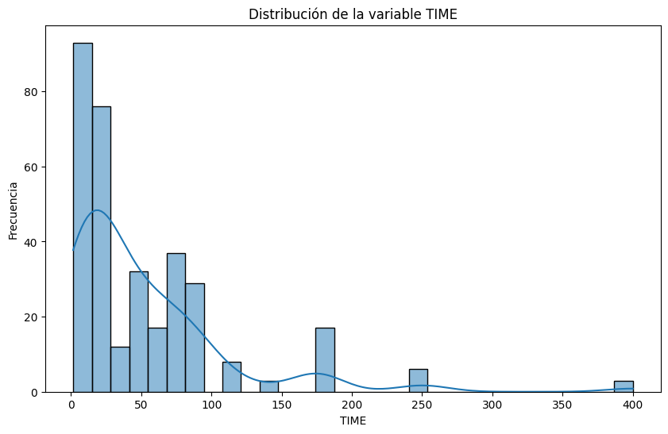

|  | metascore | GAMERS | COMP % | TIME | RATING |
| --- | --- | --- | --- | --- | --- |
| count | 357.000000 | 357.000000 | 357.000000 | 333.000000 | 357.000000 |
| mean | 78.364146 | 92863.577031 | 5.957143 | 51.876877 | 3.786275 |
| std | 8.706942 | 93055.655763 | 10.100586 | 60.668476 | 0.454326 |
| min | 43.000000 | 166.000000 | 0.000000 | 1.500000 | 2.200000 |
| 25% | 73.000000 | 23287.000000 | 0.600000 | 11.000000 | 3.500000 |
| 50% | 79.000000 | 61345.000000 | 1.900000 | 27.500000 | 3.800000 |
| 75% | 84.000000 | 128274.000000 | 6.100000 | 70.000000 | 4.100000 |
| max | 96.000000 | 455839.000000 | 62.900000 | 400.000000 | 4.800000 |

```python
plt.figure(figsize=(10, 6))
sns.histplot(df_merged[cons.TIME].dropna(), bins=30, kde=True)
plt.title('Distribución de la variable TIME')
plt.xlabel('TIME')
plt.ylabel('Frecuencia')
plt.show()

df_merged.describe()
```

Revisando los juegos que siguen con valor nulo en tiempo, se puede notar que la mayoría son juegos online, por lo que no tienen un tiempo de juego definido. Sin embargo, aun existen algunos juegos offline que no cuentan con horas de juego. Por lo tanto, se propone lo siguiente:

- Se tomará un umbral de número de jugadores para descartar algunos titulos, en este caso se eliminaran los juegos con menos de 1000 jugadores
- Al revisar la distribución de valores de la variable `TIME` y viendo sus valores estadísticos, se decide que los valores nulos restantes serán reemplazados por la mediana. Esto porque lo usual es que los videojuegos duren alrededor de 30 horas actualmente.

Además, se eliminan las columnas added y release_date ya que en este punto no serán de mucha utilidad.

```python
df_merged = df_merged[df_merged[cons.GAMERS] >= 1000]
median_time = df_merged[cons.TIME].median()
df_merged[cons.TIME].fillna(median_time, inplace=True)
df_merged = df_merged.drop(columns=[cons.ADDED, cons.RELEASE_DATE, cons.GAME])
df_merged.head()
```

[output not shown]

|  | metascore | title | user_score | GAMERS | COMP % | TIME | RATING |
| --- | --- | --- | --- | --- | --- | --- | --- |
| 483 | 78 | olija | tbd | 4380 | 14.2 | 4.5 | 3.3 |
| 802 | 68 | gang beasts | tbd | 135527 | 9.3 | 1.5 | 2.9 |
| 894 | 56 | recompile | tbd | 7808 | 6.1 | 7.0 | 3.2 |
| 852 | 65 | moonglow bay | tbd | 4060 | 2.9 | 45.0 | 3.5 |
| 699 | 72 | lawn mowing simulator | tbd | 33974 | 0.1 | 70.0 | 3.3 |

```python
df_merged.info()
```

```
<class 'pandas.core.frame.DataFrame'>
Index: 354 entries, 483 to 777
Data columns (total 7 columns):
 #   Column      Non-Null Count  Dtype
---  ------      --------------  -----
 0   metascore   354 non-null    int64
 1   title       354 non-null    object
 2   user_score  354 non-null    object
 3   GAMERS      354 non-null    int64
 4   COMP %      354 non-null    float64
 5   TIME        354 non-null    float64
 6   RATING      354 non-null    float64
dtypes: float64(3), int64(2), object(2)
memory usage: 22.1+ KB
```

Ahora surge otro problema: `user_score` tiene valores no numéricos y además hay registros con valor tbd. Antes de darles un tratamiento, se determina cuántos hay

```python
non_numeric_user_score_count = df_merged[~df_merged[cons.USER_SCORE].apply(lambda x: x.replace('.', '', 1).isdigit())].shape[0]
print(f"Valores no numéricos en 'user_score': {non_numeric_user_score_count}")
```

```
Valores no numéricos en 'user_score': 5
```

Al ser pocos, se pueden reemplazar con 0 y la variable se convierte en numérica.

```python
df_merged[cons.USER_SCORE] = df_merged[cons.USER_SCORE].apply(lambda x: 0 if not x.replace('.', '', 1).isdigit() else x)
df_merged[cons.USER_SCORE] = pd.to_numeric(df_merged[cons.USER_SCORE])
df_merged.info()
```

```
<class 'pandas.core.frame.DataFrame'>
Index: 354 entries, 483 to 777
Data columns (total 7 columns):
 #   Column      Non-Null Count  Dtype
---  ------      --------------  -----
 0   metascore   354 non-null    int64
 1   title       354 non-null    object
 2   user_score  354 non-null    float64
 3   GAMERS      354 non-null    int64
 4   COMP %      354 non-null    float64
 5   TIME        354 non-null    float64
 6   RATING      354 non-null    float64
dtypes: float64(4), int64(2), object(1)
memory usage: 22.1+ KB
```

Finalmente, se reemplazan los nombres de las columnas para una mejor comprensión y se normalizan las valoraciones. Para tener las valoraciones normalizadas, se cambian los campos `xbox_user_score` y `metacritic_user_score` a una escala de 0 a 100 y `metascore` a tipo de dato float.

```python
df_merged.rename(columns={cons.RATING: cons.XBOX, cons.USER_SCORE: cons.METACRITIC_USER_SCORE}, inplace=True)
df_merged['xbox_user_score'] = df_merged['xbox_user_score'] * 20
df_merged['metacritic_user_score'] = df_merged['metacritic_user_score'] * 10
df_merged['metascore'] = df_merged['metascore'].astype(float)
df_merged.reset_index(drop=True, inplace=True)
df_merged.head()
```

|  | metascore | title | metacritic_user_score | GAMERS | COMP % | TIME | xbox_user_score |
| --- | --- | --- | --- | --- | --- | --- | --- |
| 0 | 78.0 | olija | 0.0 | 4380 | 14.2 | 4.5 | 66.0 |
| 1 | 68.0 | gang beasts | 0.0 | 135527 | 9.3 | 1.5 | 58.0 |
| 2 | 56.0 | recompile | 0.0 | 7808 | 6.1 | 7.0 | 64.0 |
| 3 | 65.0 | moonglow bay | 0.0 | 4060 | 2.9 | 45.0 | 70.0 |
| 4 | 72.0 | lawn mowing simulator | 0.0 | 33974 | 0.1 | 70.0 | 66.0 |

Con esto, se puede empezar con el análisis.

## Análisis

Para una mejor comprensión de cada variable, la siguiente tabla detalla de que va cada una

| Columna/Variable | Descripción | Tipo | Importancia | Nota |
| --- | --- | --- | --- | --- |
| metascore | Indica la valoración dada por los críticos avalados por Metacritic de cada título | Numérica | Alta | Nos ayuda a saber el veredicto de los "expertos". |
| title | Nombre de cada videojuego | Categórica | Media | Ayuda a identificar el nombre del juego, pero en este análisis damos más peso a sus valoraciones. |
| metacritic_user_score | Valoración por los usuarios/jugadores suscritos en Metacritic, pero que no tienen ese "plus" de ser críticos avalados por la plataforma | Numérica | Alta | Aunque hay expertos que dan valoraciones a los videojuegos, la comunidad también tiene voz y peso en sus opiniones. |
| GAMERS | Número de jugadores que han jugado el título | Numérica | Alta | Con el número de jugadores podemos determinar el impacto que tuvo el título desde que se añadió al catálogo. |
| COMP % | Porcentaje de jugadores que han completado el título | Numérica | Alta | Nos ayuda a saber cuántos jugadores han aprovechado el servicio para completar los títulos en el catálogo. |
| TIME | Tiempo medio para completar el título | Numérica | Media | Puede ayudarnos a saber cuánto tiempo tarda un jugador en promedio para completar el título y analizar si es un factor clave. |
| xbox_user_score | Calificación del título dada por usuarios de Xbox | Numérica | Media | Aunque es una valoración dada por usuarios de Xbox, no nos da mucha certeza, ya que se restringe a usuarios de esta plataforma y son pocas las calificaciones. |

Ahora, se harán análisis univariantes, bivariantes y multivariantes.

### Análisis univariante

Empezamos haciendo un análisis univariante de cada variable numérica para entender su distribución (ya que son las que nos interesan en ese análisis).

```python
numeric_columns = df_merged.select_dtypes(include=[np.number]).columns
df_merged[numeric_columns].describe()
```

|  | metascore | metacritic_user_score | GAMERS | COMP % | TIME | xbox_user_score |
| --- | --- | --- | --- | --- | --- | --- |
| count | 354.000000 | 354.000000 | 354.000000 | 354.000000 | 354.000000 | 354.000000 |
| mean | 78.437853 | 70.988701 | 93647.059322 | 6.007627 | 50.430791 | 75.870056 |
| std | 8.693577 | 16.304291 | 93057.468284 | 10.128412 | 59.118143 | 8.975576 |
| min | 43.000000 | 0.000000 | 1065.000000 | 0.000000 | 1.500000 | 44.000000 |
| 25% | 73.000000 | 67.000000 | 23690.250000 | 0.600000 | 13.500000 | 70.000000 |
| 50% | 79.500000 | 75.000000 | 62594.500000 | 1.900000 | 27.500000 | 76.000000 |
| 75% | 84.750000 | 81.000000 | 131071.500000 | 6.100000 | 70.000000 | 82.000000 |
| max | 96.000000 | 96.000000 | 455839.000000 | 62.900000 | 400.000000 | 96.000000 |

Graficamos histogramas de las variables numéricas.

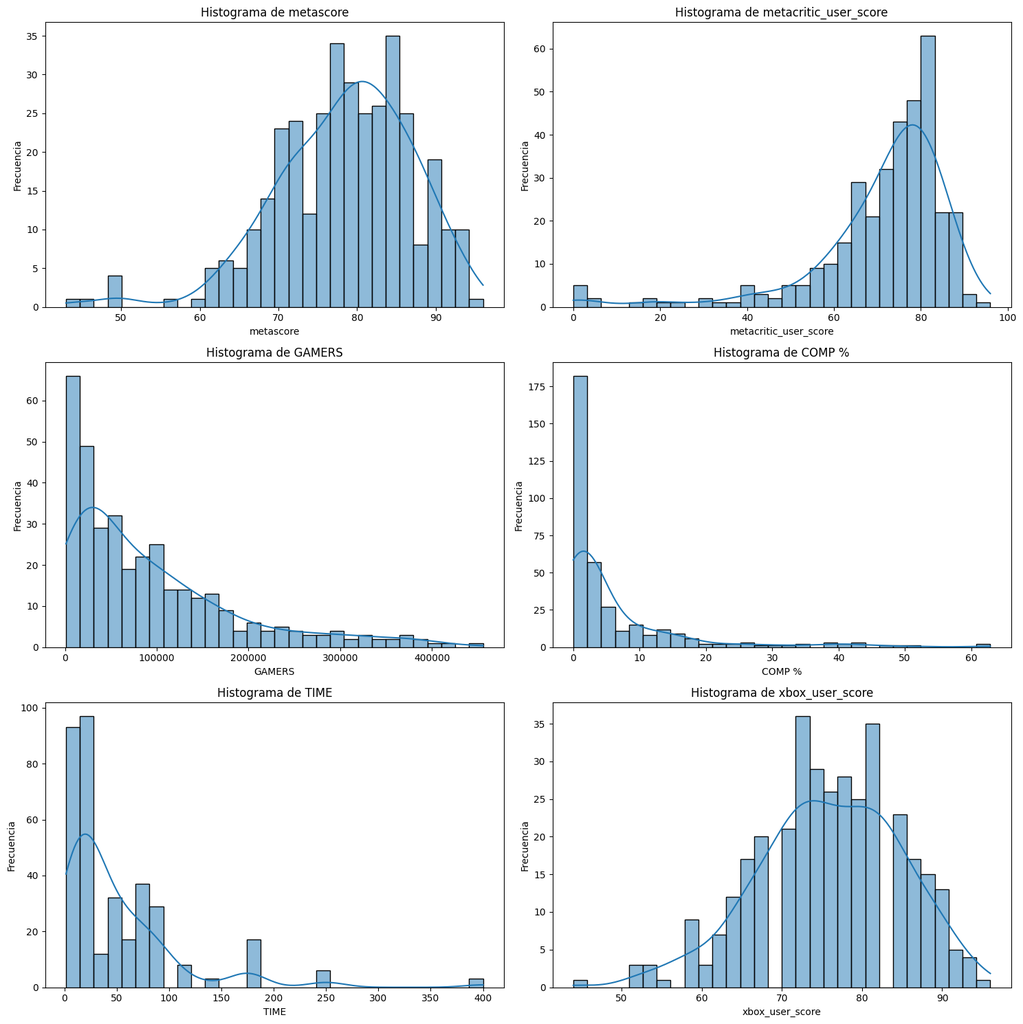

```python
funtils.plot_numerical_histograms(df_merged, numeric_columns, bins_list=[30,30,30,30,30,30], kde=True)
```

Revisando las gráficas, se pueden tener unas primeras conclusiones:

- En su debida proporción, las valoraciones dadas por criticos de Metacritic, usuarios de Metacritic y usuarios de Xbox en el valor máximo pero los estadísticos de las valoraciones de críticos de Metacritic y usuarios de Xbox se parecen mucho más.
- Como se vió antes, hay juegos que durán alrededor de 30 horas en su mayoría.
- Después de hacer el corte de número de jugadores en cada juego, se tiene una media significativa de alrededor de 100,000 jugadores
- Hay bastantes juegos que no han sido completados, ni siquiera llevan un 10% de completado. Habría que analizar que valoraciones tienen esos juegos.

### Análisis bivariante

Para el análisis bivariante, se harán unas variables categóricas de cada variable de valoración teniendo 5 categorías para cada uno: "Muy positivas", "Positivas", "Variadas", "Negativas" y "Muy negativas".

```python
df_merged[cons.METACRITIC_USER_SCORE_CAT] = funtils.categorize_score(df_merged[cons.METACRITIC_USER_SCORE], cons.CAT_BINS, cons.CAT_VALS)
df_merged[cons.XBOX_USER_SCORE_CAT] = funtils.categorize_score(df_merged[cons.XBOX], cons.CAT_BINS, cons.CAT_VALS)
df_merged[cons.METASCORE_CAT] = funtils.categorize_score(df_merged[cons.METASCORE], cons.CAT_BINS, cons.CAT_VALS)
df_merged.head()
```

|  | metascore | title | metacritic_user_score | GAMERS | COMP % | TIME | xbox_user_score | metacritic_user_score_cat | xbox_user_score_cat | metascore_cat |
| --- | --- | --- | --- | --- | --- | --- | --- | --- | --- | --- |
| 0 | 78.0 | olija | 0.0 | 4380 | 14.2 | 4.5 | 66.0 | Muy negativas | Positivas | Positivas |
| 1 | 68.0 | gang beasts | 0.0 | 135527 | 9.3 | 1.5 | 58.0 | Muy negativas | Variadas | Positivas |
| 2 | 56.0 | recompile | 0.0 | 7808 | 6.1 | 7.0 | 64.0 | Muy negativas | Positivas | Variadas |
| 3 | 65.0 | moonglow bay | 0.0 | 4060 | 2.9 | 45.0 | 70.0 | Muy negativas | Positivas | Positivas |
| 4 | 72.0 | lawn mowing simulator | 0.0 | 33974 | 0.1 | 70.0 | 66.0 | Muy negativas | Positivas | Positivas |

Con estas nuevas variables, será más sencillo el análisis con las valoraciones.

#### Análisis entre categóricas y numéricas

Para este análisis, se usarán boxplots (que sirve para interpretar los datos estadísticos) e histogramas (esto nos servirá para presentar resultados).

Empezamos con los boxplots.

[output not shown]

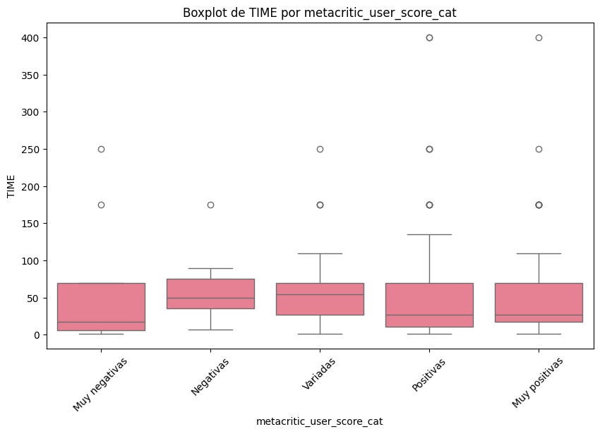

[output not shown]

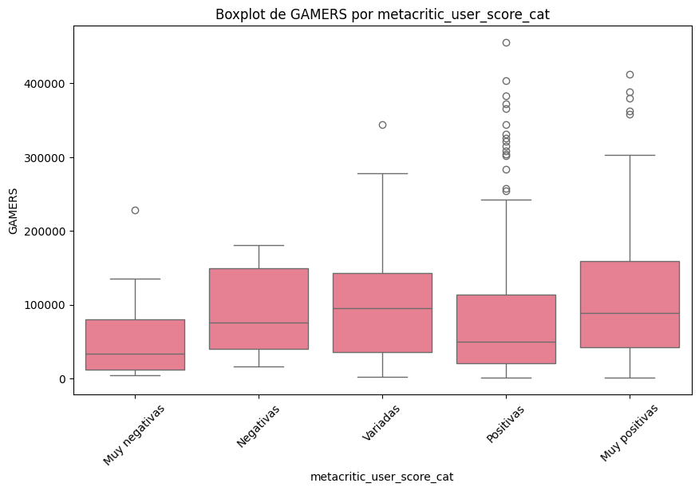

[output not shown]

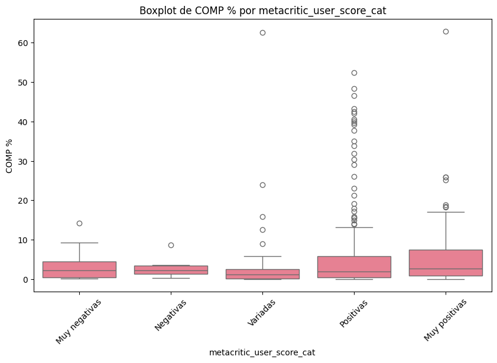

[output not shown]

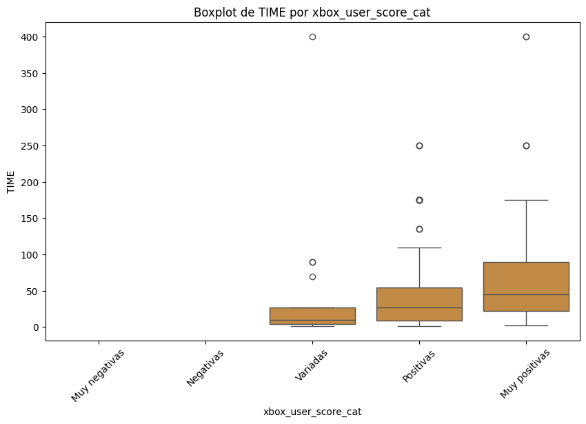

[output not shown]

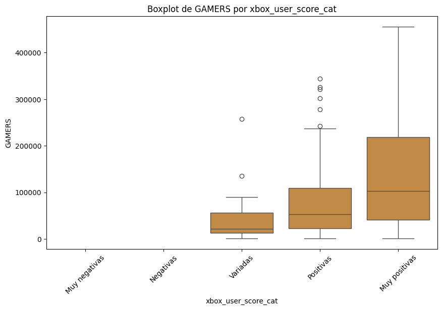

[output not shown]

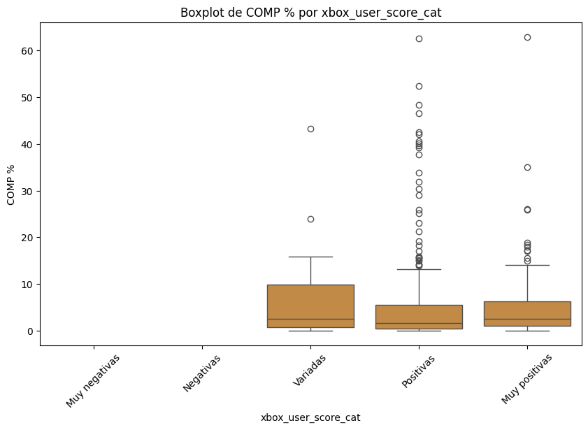

[output not shown]

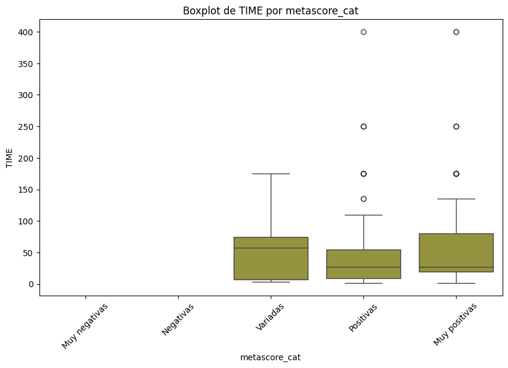

[output not shown]

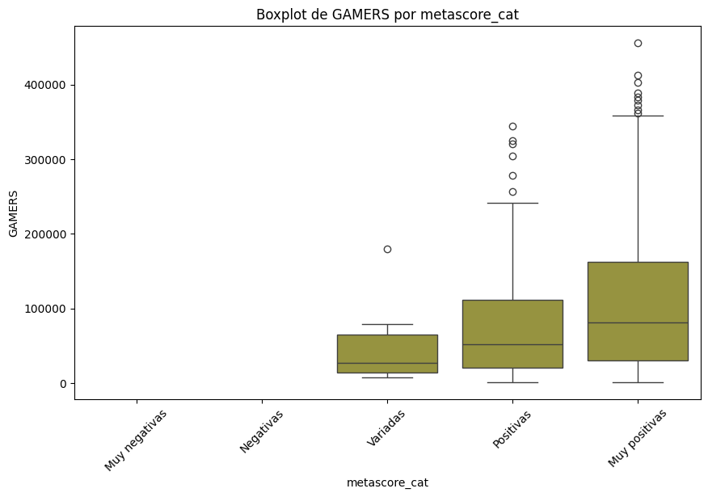

[output not shown]

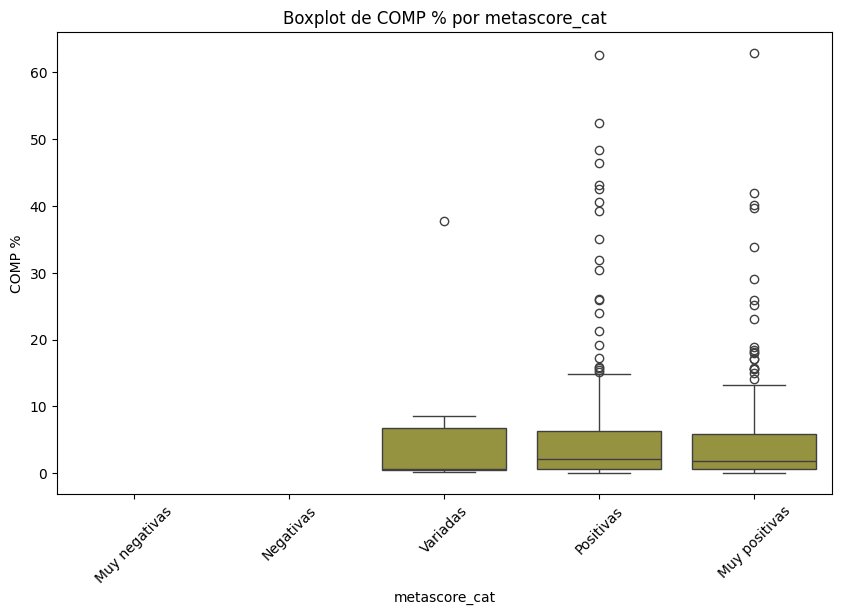

```python
categorical_columns = [cons.METACRITIC_USER_SCORE_CAT, cons.XBOX_USER_SCORE_CAT, cons.METASCORE_CAT]
numerical_columns_s = [cons.TIME, cons.GAMERS, cons.COMP]

funtils.plot_categorical_numerical_boxplots(df_merged, categorical_columns, numerical_columns_s)
```

Continuamos con los histogramas.

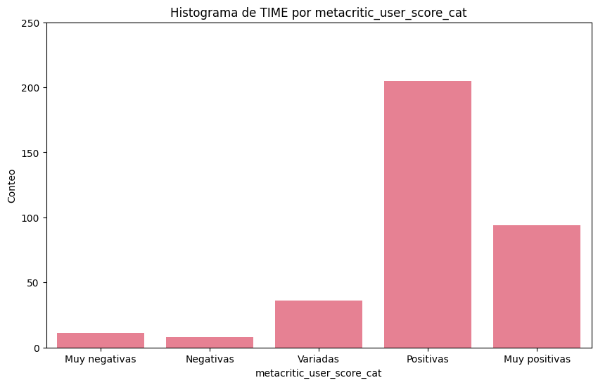

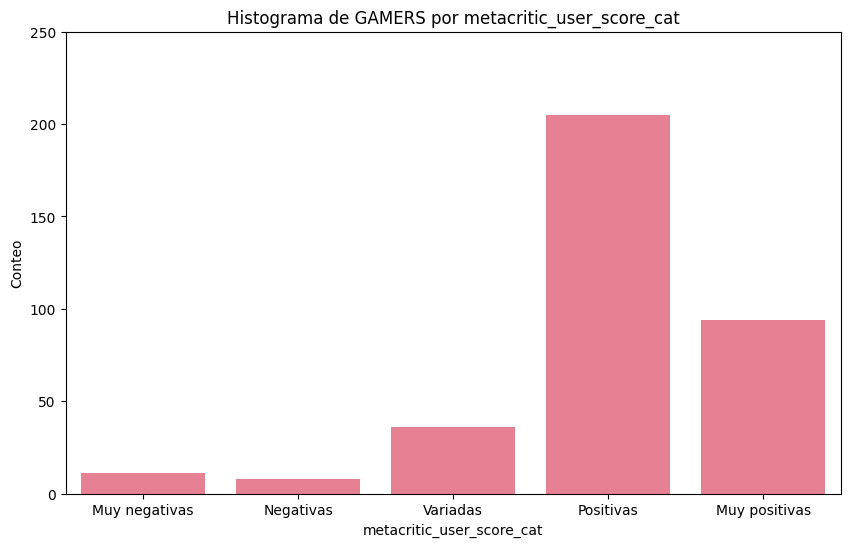

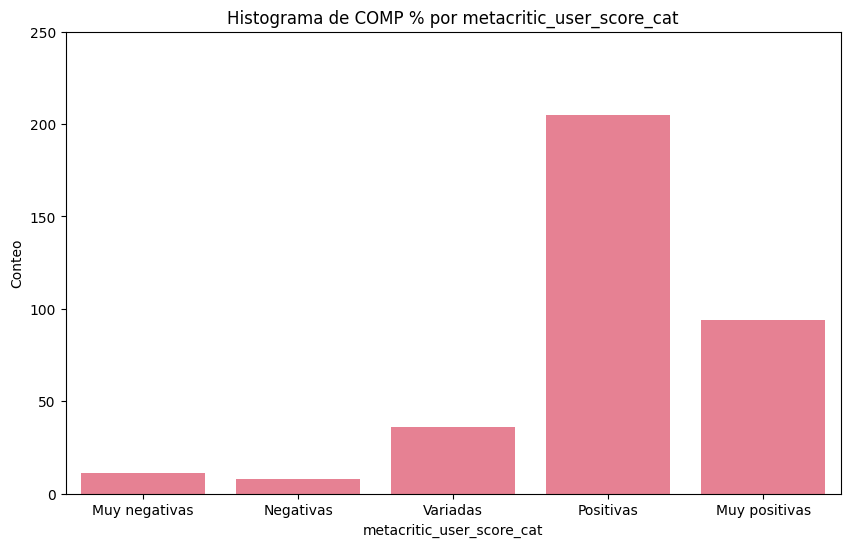

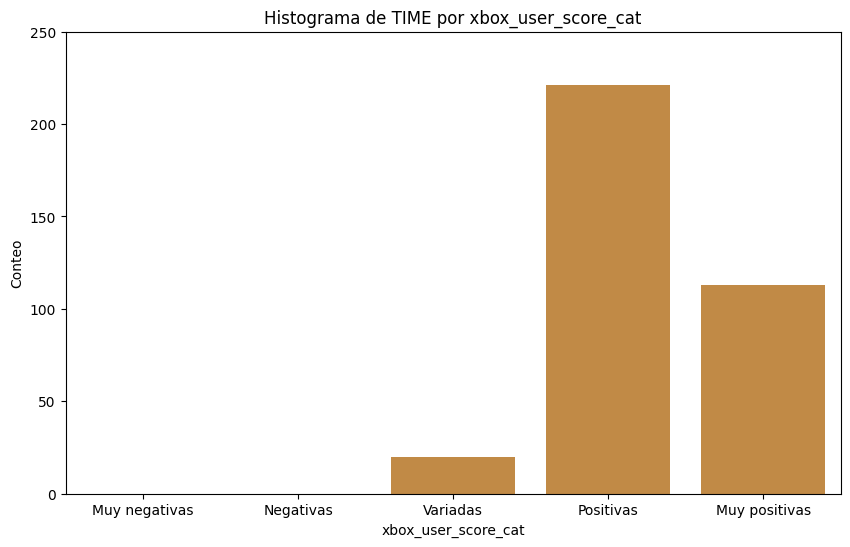

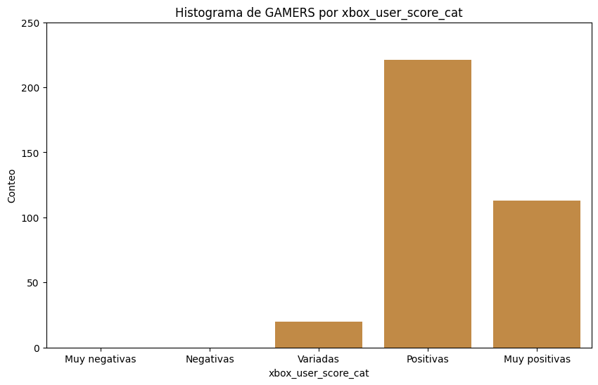

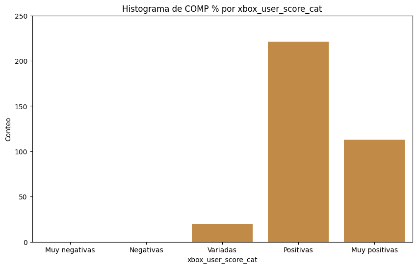

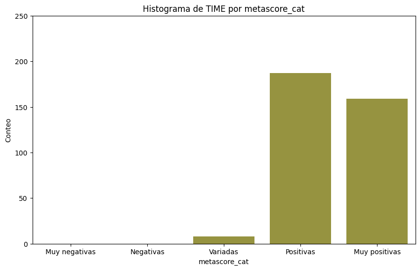

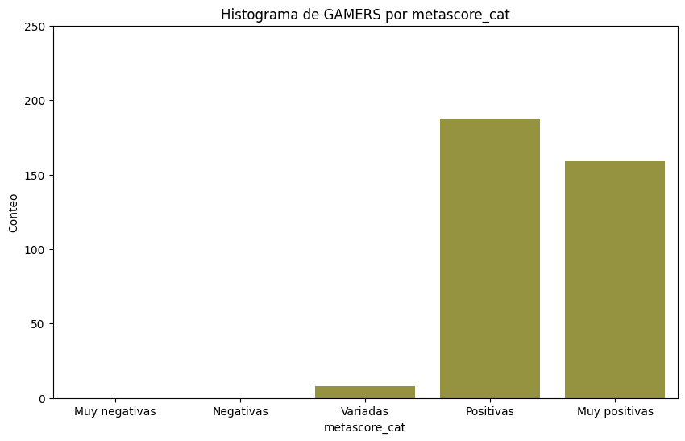

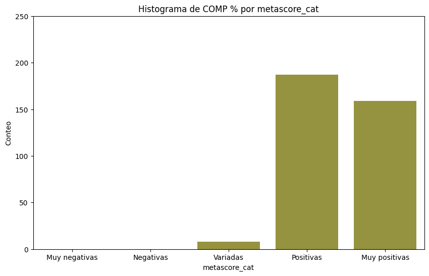

```python
funtils.plot_categorical_numerical_histograms(df_merged, categorical_columns, numerical_columns_s)
```

Se revisarán algunos registros en los que `metacritic_user_score_cat` caen en la categoría 'Muy negativas' y ver si son valores igual a cero

```python
df_merged[(df_merged[cons.METACRITIC_USER_SCORE_CAT] == 'Muy negativas')].sort_values(by=cons.METACRITIC_USER_SCORE_CAT, ascending=False)
```

|  | metascore | title | metacritic_user_score | GAMERS | COMP % | TIME | xbox_user_score | metacritic_user_score_cat | xbox_user_score_cat | metascore_cat |
| --- | --- | --- | --- | --- | --- | --- | --- | --- | --- | --- |
| 0 | 78.0 | olija | 0.0 | 4380 | 14.2 | 4.5 | 66.0 | Muy negativas | Positivas | Positivas |
| 1 | 68.0 | gang beasts | 0.0 | 135527 | 9.3 | 1.5 | 58.0 | Muy negativas | Variadas | Positivas |
| 2 | 56.0 | recompile | 0.0 | 7808 | 6.1 | 7.0 | 64.0 | Muy negativas | Positivas | Variadas |
| 3 | 65.0 | moonglow bay | 0.0 | 4060 | 2.9 | 45.0 | 70.0 | Muy negativas | Positivas | Positivas |
| 4 | 72.0 | lawn mowing simulator | 0.0 | 33974 | 0.1 | 70.0 | 66.0 | Muy negativas | Positivas | Positivas |
| 348 | 82.0 | ea sports ufc 4 | 20.0 | 66145 | 0.5 | 17.5 | 68.0 | Muy negativas | Positivas | Muy positivas |
| 349 | 66.0 | star wars battlefront ii | 19.0 | 228476 | 1.7 | 70.0 | 76.0 | Muy negativas | Positivas | Positivas |
| 350 | 79.0 | fifa 20 | 18.0 | 93669 | 0.3 | 175.0 | 66.0 | Muy negativas | Positivas | Positivas |
| 351 | 77.0 | fifa 21 | 15.0 | 38890 | 0.5 | 250.0 | 66.0 | Muy negativas | Positivas | Positivas |
| 352 | 70.0 | madden nfl 22 | 6.0 | 15217 | 2.2 | 3.5 | 54.0 | Muy negativas | Variadas | Positivas |
| 353 | 69.0 | madden nfl 21 | 5.0 | 22414 | 3.0 | 9.0 | 64.0 | Muy negativas | Positivas | Positivas |

La mitad de registros que son catalogados como "Muy Negativo" en `metacritic_user_score_cat` tienen un valor de cero en su homólogo numérico. Puede significar que hay usuarios que no han calificado esos títulos.

#### Análisis entre numéricas

Para el análisis entre variables numéricas, se usará un mapa de calor para determinar si hay correlación entre variables. Así mismo se usará `pairplot` para revisar gráficos de dispersión y encontrar algún patrón.

Empezamos con la matriz de correlación.

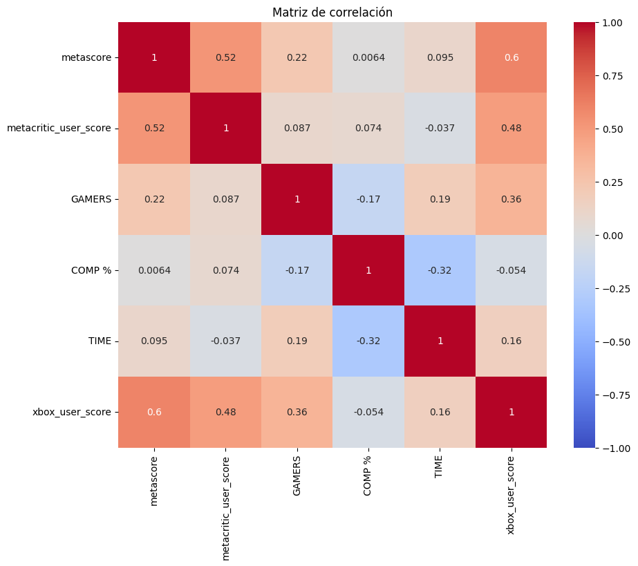

```python
correlation_matrix = df_merged[numeric_columns].corr()

plt.figure(figsize=(10, 8))
sns.heatmap(correlation_matrix, annot=True, cmap='coolwarm', vmin=-1, vmax=1)
plt.title('Matriz de correlación')
plt.show()
```

Visualizamos gráficos de dispersión para cada par de variables numéricas.

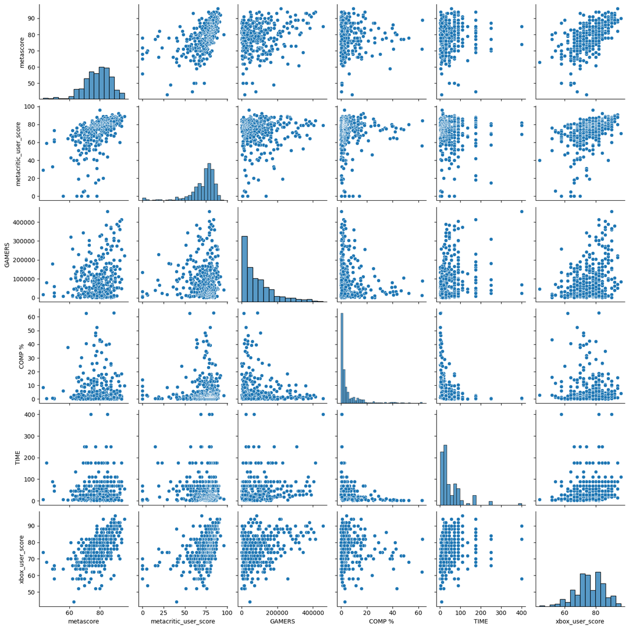

```python
sns.pairplot(df_merged[numeric_columns])
plt.show()
```

### Análisis Multivariante

En base a los análisis previos, se hará analisis multivariante entre número de jugadores, porcentaje de completado y tiempo de cada título con cada valoración categórica.

#### Número de jugadores vs porcentaje de jugadores que han completado el título

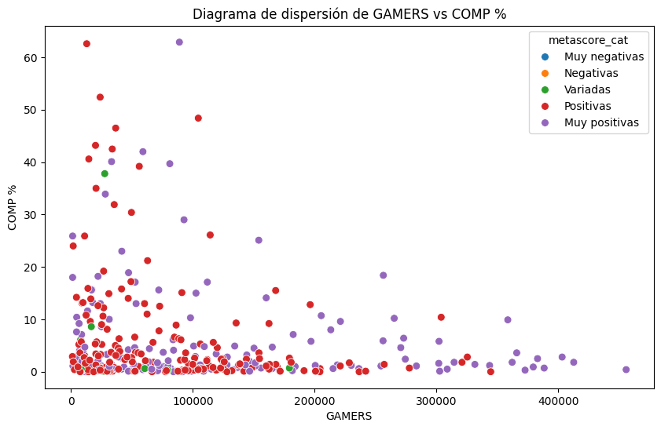

```python
funtils.plot_scatter(df_merged, cons.GAMERS, cons.COMP, cons.METASCORE_CAT)
```

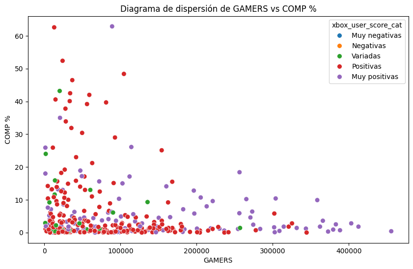

```python
funtils.plot_scatter(df_merged, cons.GAMERS, cons.COMP, cons.XBOX_USER_SCORE_CAT)
```

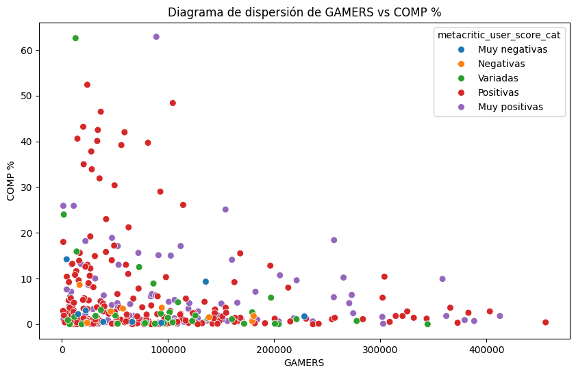

```python
funtils.plot_scatter(df_merged, cons.GAMERS, cons.COMP, cons.METACRITIC_USER_SCORE_CAT)
```

#### Número de jugadores vs tiempo medio para completar el título

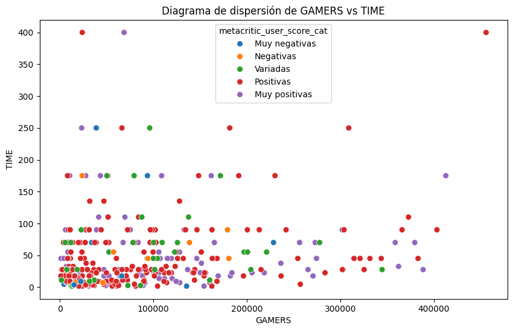

```python
funtils.plot_scatter(df_merged, cons.GAMERS, cons.TIME, cons.METACRITIC_USER_SCORE_CAT)
```

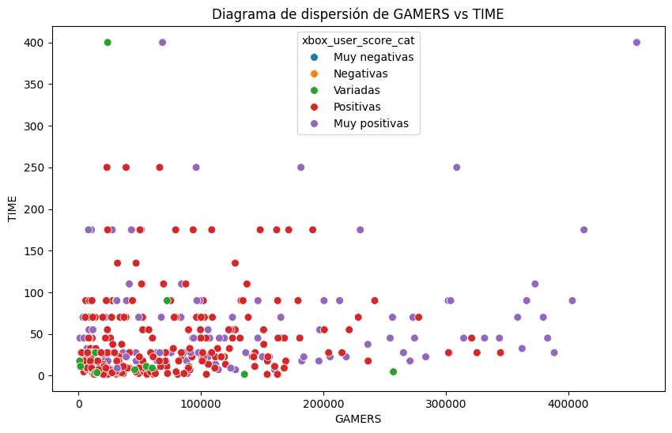

```python
funtils.plot_scatter(df_merged, cons.GAMERS, cons.TIME, cons.XBOX_USER_SCORE_CAT)
```

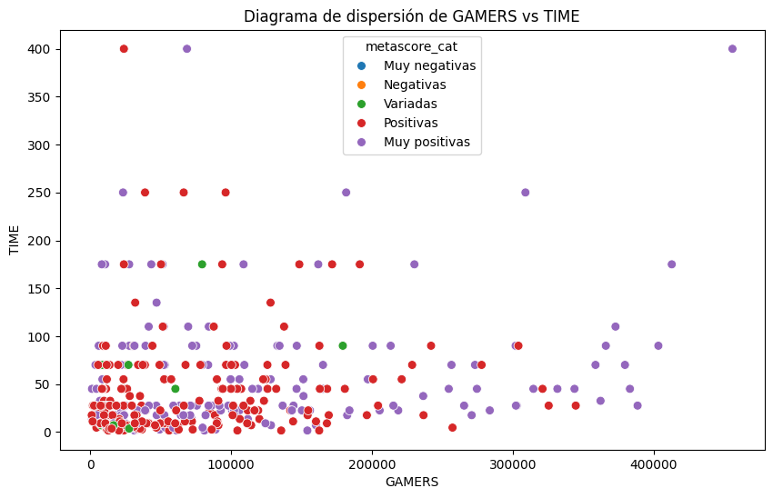

```python
funtils.plot_scatter(df_merged, cons.GAMERS, cons.TIME, cons.METASCORE_CAT)
```

#### Tiempo medio para completar el título vs porcentaje para completarlo

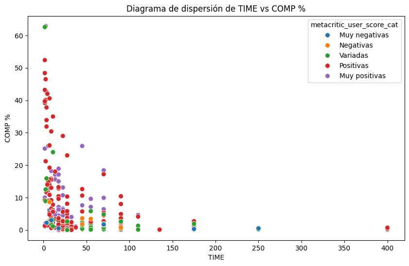

```python
funtils.plot_scatter(df_merged,  cons.TIME, cons.COMP, cons.METACRITIC_USER_SCORE_CAT)
```

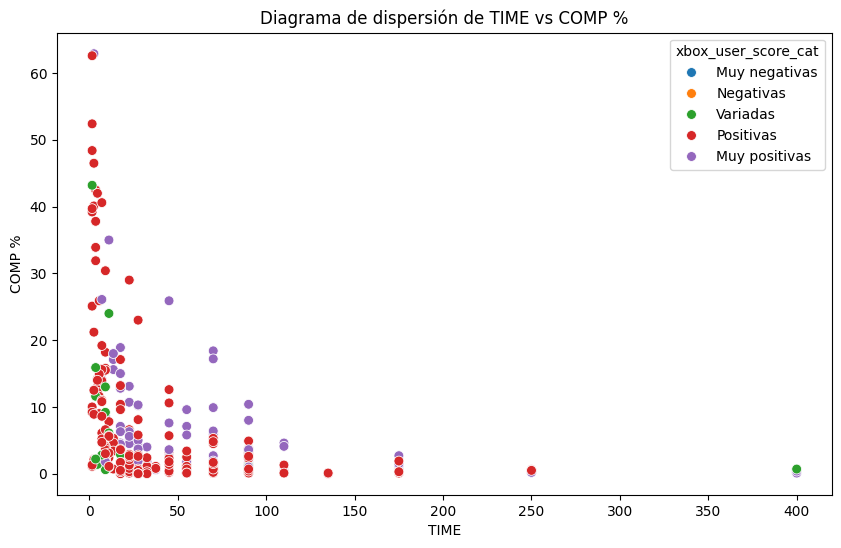

```python
funtils.plot_scatter(df_merged,  cons.TIME, cons.COMP, cons.XBOX_USER_SCORE_CAT)
```

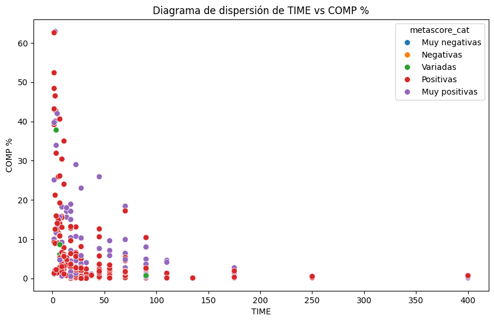

```python
funtils.plot_scatter(df_merged,  cons.TIME, cons.COMP, cons.METASCORE_CAT)
```

Para tener el análisis completo, se hace el análisis entre las tres variables numéricas

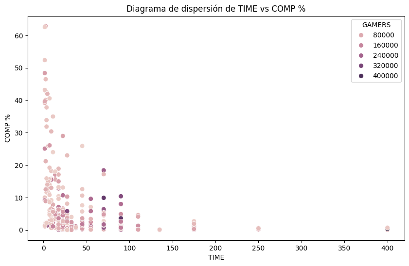

```python
funtils.plot_scatter(df_merged, cons.TIME, cons.COMP, cons.GAMERS)
```

Del análisis multivariante, se concluye:

# Conclusiones

En base a los datos obtenidos:

- **Aprovechamiento del servicio:** Se comprueba la hipótesis de que los jugadores con la suscripción de Xbox Game Pass sí aprovechan el servicio para jugar títulos muy populares por la comunidad aunque no necesariamente los terminan en un 100%.
- **Relación tiempo y valoración:** Si bien hay buenos juegos con larga duración, los jugadores prefieren juegos con una duración media de 30 horas.
- **Finalización de cada título:** No todos los juegos son completados al 100% por los jugadores aunque sean títulos con altas valoraciones. Probablemente por el tiempo medio para completarlo, se enfocan en las historias principales (en el caso de juegos offline) o solo quieren jugar un rato.
- **Valoraciones y número de jugadores:** Las valoraciones de los usuarios de Xbox y los críticos de Metacritic influyen en el número de jugadores que juegan cada título. Sin embargo, no necesariamente significa que vayan a completar los títulos de larga duración.
- **Duración del juego:** Los jugadores prefieren juegos que duren menos de 100 horas, lo cual influye en si los jugadores terminan o se acercan a completar el título.

Este análisis proporciona una visión clara sobre el uso y la rentabilidad del servicio Xbox Game Pass, ayudando a entender mejor el comportamiento de los jugadores y la relación entre la popularidad de los juegos y su calidad percibida.